# gee_infant_height

Hajin Jang

2025-10-15

### This analysis evaluated whether longitudinal changes in height-for-age z-scores during early childhood differed by socioeconomic status using repeated measurements over the first two years of life.

## About the data

The analysis used data from 200 infants followed from birth to 24 months, with height-for-age z-scores measured approximately every two months, yielding up to 13 repeated observations per child. Socioeconomic status (low vs. high) and sex were considered key covariates, and stunting was defined as HAZ < -2 at each visit. After descriptive analyses of missingness and mean HAZ trajectories by SES, generalized estimating equations were used to model population-averaged changes in HAZ over time, assess differences in growth rates between SES groups, and select an appropriate working correlation structure.

## Data cleaning

```r
knitr::opts_chunk$set(echo = TRUE)

library(tidyverse)
library(haven)
library(mice)
library(VIM)
library(MASS)
library(gee)
library(geepack)
library(geeM)
hazdata <-  read_csv("hazdata.csv")
# make factors/dummy variables for categorical data
hazdata <- hazdata %>%
  mutate(., ses = as.factor(ses),
         sex = as.factor(sex),
         stunt = as.factor(stunt))
```

## EDA

#### Missing data pattern: height-to-age z-score (HAZ)

```r
# transfer to wide data
hazdata.wide = hazdata %>%
  tidyr::pivot_wider(., id_cols = c(id, ses, sex), names_from = visit, values_from = haz)
dim(hazdata.wide)
```

```
## [1] 200  16
```

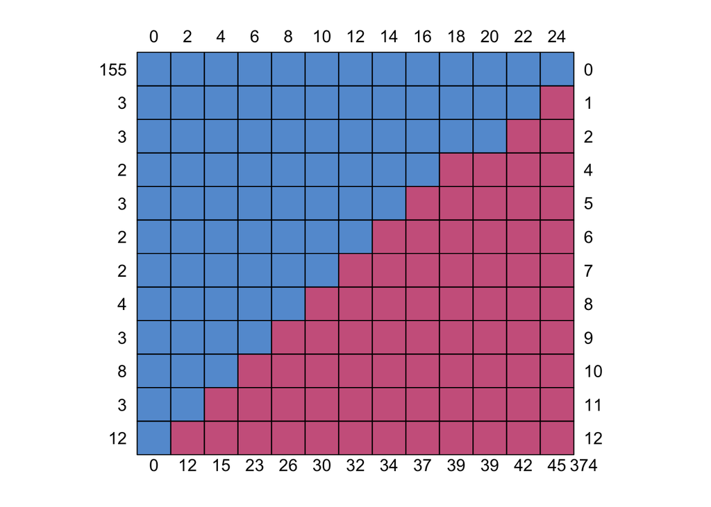

```
##     0  2  4  6  8 10 12 14 16 18 20 22 24
## 155 1  1  1  1  1  1  1  1  1  1  1  1  1   0
## 3   1  1  1  1  1  1  1  1  1  1  1  1  0   1
## 3   1  1  1  1  1  1  1  1  1  1  1  0  0   2
## 2   1  1  1  1  1  1  1  1  1  0  0  0  0   4
## 3   1  1  1  1  1  1  1  1  0  0  0  0  0   5
## 2   1  1  1  1  1  1  1  0  0  0  0  0  0   6
## 2   1  1  1  1  1  1  0  0  0  0  0  0  0   7
## 4   1  1  1  1  1  0  0  0  0  0  0  0  0   8
## 3   1  1  1  1  0  0  0  0  0  0  0  0  0   9
## 8   1  1  1  0  0  0  0  0  0  0  0  0  0  10
## 3   1  1  0  0  0  0  0  0  0  0  0  0  0  11
## 12  1  0  0  0  0  0  0  0  0  0  0  0  0  12
##     0 12 15 23 26 30 32 34 37 39 39 42 45 374
```

```r
# missing pattern
mice::md.pattern(hazdata.wide[,4:16])
```

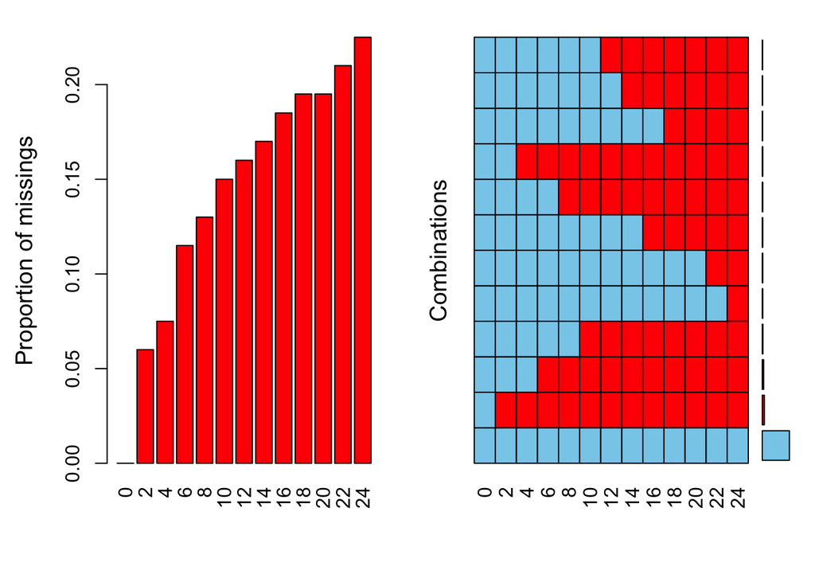

```
##
##  Missings per variable:
##  Variable Count
##         0     0
##         2    12
##         4    15
##         6    23
##         8    26
##        10    30
##        12    32
##        14    34
##        16    37
##        18    39
##        20    39
##        22    42
##        24    45
##
##  Missings in combinations of variables:
##               Combinations Count Percent
##  0:0:0:0:0:0:0:0:0:0:0:0:0   155    77.5
##  0:0:0:0:0:0:0:0:0:0:0:0:1     3     1.5
##  0:0:0:0:0:0:0:0:0:0:0:1:1     3     1.5
##  0:0:0:0:0:0:0:0:0:1:1:1:1     2     1.0
##  0:0:0:0:0:0:0:0:1:1:1:1:1     3     1.5
##  0:0:0:0:0:0:0:1:1:1:1:1:1     2     1.0
##  0:0:0:0:0:0:1:1:1:1:1:1:1     2     1.0
##  0:0:0:0:0:1:1:1:1:1:1:1:1     4     2.0
##  0:0:0:0:1:1:1:1:1:1:1:1:1     3     1.5
##  0:0:0:1:1:1:1:1:1:1:1:1:1     8     4.0
##  0:0:1:1:1:1:1:1:1:1:1:1:1     3     1.5
##  0:1:1:1:1:1:1:1:1:1:1:1:1    12     6.0
```

```r
summary(VIM::aggr(hazdata.wide[,4:16]))
```

**Complete case:**155/200 = 77.5%

**Monotonic missingness:** (3+3+2+3+2+2+4+3+8+3+12)/200 = 22.5%

**Intermittent missingness:** 0

#### Mean trajectories of the height-to-age z score by SES

```r
# Numerical descriptive statistics
hazdata %>%
  group_by(ses) %>%
  summarise(.,
                   n = sum(!is.na(haz)),
                   minimum = min(haz, na.rm = T),
                   q25 = quantile(haz, probs = 0.25, na.rm = T),
                   med = median(haz, na.rm = T),
                   q75 = quantile(haz, probs = 0.75, na.rm = T),
                   maximum = max(haz, na.rm = T),
                   average = mean(haz, na.rm = T),
                   sd = num(sd(haz, na.rm = T), digits = 2) )
```

```
## # A tibble: 2 × 9
##   ses       n minimum   q25    med    q75 maximum average        sd
##   <fct> <int>   <dbl> <dbl>  <dbl>  <dbl>   <dbl>   <dbl> <num:.2!>
## 1 0      1383   -3.77 -2.09 -1.44  -0.674    1.45  -1.37       0.96
## 2 1       843   -2.53 -1.36 -0.894 -0.306    1.45  -0.827      0.76
```

[output not shown]

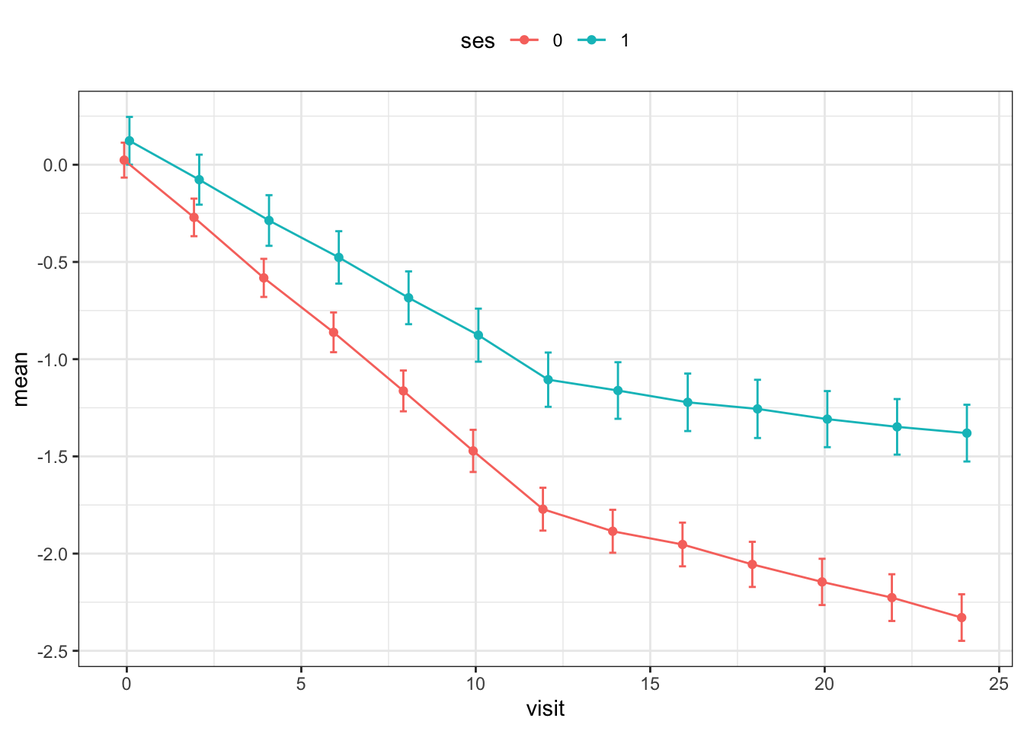

```r
# Graphical descriptive statistics
## Mean trajectory plot by SES
hazdata %>%
  dplyr::group_by(ses, visit) %>%
  dplyr::summarise(n = sum(!is.na(haz)),
                   mean = mean(haz, na.rm = T),
                   sd = sd(haz, na.rm = T),
                   se = sd/sqrt(n)) %>%
  ggplot2::ggplot(., aes(x = visit, y = mean, color = ses)) +
  ggplot2::geom_errorbar(aes(ymin = mean - 1.96*se, ymax = mean + 1.96*se),
                         position = position_dodge(0.3), width = 0.4) +
  ggplot2::geom_point(position = position_dodge(0.3)) +
  ggplot2::geom_line(position = position_dodge(0.3)) +
  ggplot2::theme_bw() +
  ggplot2::theme(legend.position = "top")
```

## GEE

#### GEE model equation

$$E(HAZ_{ij}) = \beta_0 + \beta_1(SES_i) + \beta_2(Sex_i) +
\beta_3(Visit_{ij}) + \beta_4(SES_i \times Visit_{ij})$$

**where:**

- $i$ indexes subjects (children) and $j$ indexes measurement occasions (visits).
- $HAZ_{ij}$: height-for-age z-score for child *i* at visit *j*.
- $SES_i$: socioeconomic status (1 = high, 0 = low).
- $Sex_i$: child’s sex (1 = male, 0 = female).
- $Visit_{ij}$: child’s age in months at each visit, modeled as a **continuous** variable.

**Model interpretation:**

- $\beta_0$: expected mean HAZ at birth for low-SES females (reference group).
- $\beta_1$: difference in baseline HAZ between high- and low-SES children.
- $\beta_2$: difference in HAZ between males and females.
- $\beta_3$: rate of change in HAZ per month for low-SES children.
- $\beta_4$: additional monthly change in HAZ for high-SES children relative to low-SES children.

```r
# observed total correlation
cor(hazdata.wide[,4:16], use = "complete.obs")
```

```
##            0         2         4         6         8        10        12
## 0  1.0000000 0.9782173 0.9462072 0.9231385 0.8966800 0.8664319 0.8357617
## 2  0.9782173 1.0000000 0.9773036 0.9557527 0.9300854 0.9031641 0.8790949
## 4  0.9462072 0.9773036 1.0000000 0.9831886 0.9642746 0.9436597 0.9222598
## 6  0.9231385 0.9557527 0.9831886 1.0000000 0.9868428 0.9692812 0.9497166
## 8  0.8966800 0.9300854 0.9642746 0.9868428 1.0000000 0.9859262 0.9687677
## 10 0.8664319 0.9031641 0.9436597 0.9692812 0.9859262 1.0000000 0.9879844
## 12 0.8357617 0.8790949 0.9222598 0.9497166 0.9687677 0.9879844 1.0000000
## 14 0.8093164 0.8539959 0.8991376 0.9280961 0.9519812 0.9738952 0.9873065
## 16 0.7976185 0.8444003 0.8906548 0.9169877 0.9419447 0.9641135 0.9780053
## 18 0.7720053 0.8222932 0.8723017 0.8978531 0.9259673 0.9495287 0.9652928
## 20 0.7558564 0.8080440 0.8571659 0.8859287 0.9157551 0.9426331 0.9585430
## 22 0.7351905 0.7860273 0.8376033 0.8666347 0.9009836 0.9300176 0.9485455
## 24 0.7114475 0.7646754 0.8208856 0.8501140 0.8867500 0.9193920 0.9403593
##           14        16        18        20        22        24
## 0  0.8093164 0.7976185 0.7720053 0.7558564 0.7351905 0.7114475
## 2  0.8539959 0.8444003 0.8222932 0.8080440 0.7860273 0.7646754
## 4  0.8991376 0.8906548 0.8723017 0.8571659 0.8376033 0.8208856
## 6  0.9280961 0.9169877 0.8978531 0.8859287 0.8666347 0.8501140
## 8  0.9519812 0.9419447 0.9259673 0.9157551 0.9009836 0.8867500
## 10 0.9738952 0.9641135 0.9495287 0.9426331 0.9300176 0.9193920
## 12 0.9873065 0.9780053 0.9652928 0.9585430 0.9485455 0.9403593
## 14 1.0000000 0.9891434 0.9799763 0.9700659 0.9601037 0.9533093
## 16 0.9891434 1.0000000 0.9897532 0.9794561 0.9704253 0.9597744
## 18 0.9799763 0.9897532 1.0000000 0.9902607 0.9816498 0.9726331
## 20 0.9700659 0.9794561 0.9902607 1.0000000 0.9891365 0.9790842
## 22 0.9601037 0.9704253 0.9816498 0.9891365 1.0000000 0.9907235
## 24 0.9533093 0.9597744 0.9726331 0.9790842 0.9907235 1.0000000
```

**Comment:** The correlation output indicates that correlations decrease over time in this longitudinal dataset.

**Treatment of time variable:** Time was modeled as continuous since the visits were measured regularly (every two months) and the goal is to estimate a linear rate of change in HAZ across early childhood. This provides a parsimonious model and allows clear interpretation of growth rate differences between SES groups.

#### Working correlation matrix initiation

Given the correlation output indicating a decline in correlations over time, I plan to use an AR(1) correlation structure, which assumes that observations taken closer in time are more strongly correlated than those further apart.also Since HAZ measurements are taken every two months, and it is reasonable to expect correlations to decay over time.

#### Checking assumptions

**Assumptions:** 1. Individuals represent a random sample from the population of interest.

2. Observations from different subjects (clusters) are independent.
3. Repeated measures from the same subject (cluster) are not independent.
4. If there are missing data, they are Missing Completely at Random (MCAR).

#### Fitting the GEE model

```r
gee.ar = geepack::geeglm(haz ~ ses + sex + visit + ses*visit, id = id, data = hazdata,
                               family = gaussian(link="identity"), corstr = "ar1")
summary(gee.ar)
```

```
##
## Call:
## geepack::geeglm(formula = haz ~ ses + sex + visit + ses * visit,
##     family = gaussian(link = "identity"), data = hazdata, id = id,
##     corstr = "ar1")
##
##  Coefficients:
##             Estimate  Std.err     Wald Pr(>|W|)
## (Intercept) -0.07361  0.05503    1.789    0.181
## ses1         0.10691  0.07629    1.964    0.161
## sex1         0.10043  0.07433    1.826    0.177
## visit       -0.10052  0.00146 4741.931   <2e-16 ***
## ses1:visit   0.03701  0.00228  263.438   <2e-16 ***
## ---
## Signif. codes:  0 '***' 0.001 '**' 0.01 '*' 0.05 '.' 0.1 ' ' 1
##
## Correlation structure = ar1
## Estimated Scale Parameters:
##
##             Estimate Std.err
## (Intercept)   0.3854 0.02653
##   Link = identity
##
## Estimated Correlation Parameters:
##       Estimate  Std.err
## alpha   0.9644 0.004617
## Number of clusters:   200  Maximum cluster size: 13
```

#### Testing working correlation matrix

```r
# independence matrix:
gee.indep = geepack::geeglm(haz ~ ses + sex + visit + ses*visit, id = id, data = hazdata,
                                  family = gaussian(link="identity"), corstr = "independence")
summary(gee.indep)
```

```
##
## Call:
## geepack::geeglm(formula = haz ~ ses + sex + visit + ses * visit,
##     family = gaussian(link = "identity"), data = hazdata, id = id,
##     corstr = "independence")
##
##  Coefficients:
##             Estimate  Std.err    Wald Pr(>|W|)
## (Intercept) -0.28097  0.05932   22.43  2.2e-06 ***
## ses1         0.16034  0.08046    3.97    0.046 *
## sex1         0.09214  0.08134    1.28    0.257
## visit       -0.10013  0.00183 2994.86  < 2e-16 ***
## ses1:visit   0.03565  0.00295  145.58  < 2e-16 ***
## ---
## Signif. codes:  0 '***' 0.001 '**' 0.01 '*' 0.05 '.' 0.1 ' ' 1
##
## Correlation structure = independence
## Estimated Scale Parameters:
##
##             Estimate Std.err
## (Intercept)    0.348  0.0261
## Number of clusters:   200  Maximum cluster size: 13
```

```r
# exchangeable matrix:
gee.exch = geepack::geeglm(haz ~ ses + sex + visit + ses*visit, id = id, data = hazdata,
                                family = gaussian(link="identity"), corstr = "exchangeable")
summary(gee.exch)
```

```
##
## Call:
## geepack::geeglm(formula = haz ~ ses + sex + visit + ses * visit,
##     family = gaussian(link = "identity"), data = hazdata, id = id,
##     corstr = "exchangeable")
##
##  Coefficients:
##             Estimate  Std.err    Wald Pr(>|W|)
## (Intercept) -0.27116  0.05679   22.80  1.8e-06 ***
## ses1         0.15161  0.07896    3.69    0.055 .
## sex1         0.09360  0.07681    1.48    0.223
## visit       -0.09877  0.00147 4535.06  < 2e-16 ***
## ses1:visit   0.03482  0.00239  212.16  < 2e-16 ***
## ---
## Signif. codes:  0 '***' 0.001 '**' 0.01 '*' 0.05 '.' 0.1 ' ' 1
##
## Correlation structure = exchangeable
## Estimated Scale Parameters:
##
##             Estimate Std.err
## (Intercept)    0.348  0.0261
##   Link = identity
##
## Estimated Correlation Parameters:
##       Estimate Std.err
## alpha    0.844  0.0265
## Number of clusters:   200  Maximum cluster size: 13
```

```r
# unstructured matrix:
gee.unst = geepack::geeglm(haz ~ ses + sex + visit + ses*visit, id = id, data = hazdata,
                                family = gaussian(link="identity"), corstr = "unstructured")
summary(gee.unst)
```

```
##
## Call:
## geepack::geeglm(formula = haz ~ ses + sex + visit + ses * visit,
##     family = gaussian(link = "identity"), data = hazdata, id = id,
##     corstr = "unstructured")
##
##  Coefficients:
##             Estimate  Std.err   Wald Pr(>|W|)
## (Intercept) -0.12872  0.12279   1.10     0.29
## ses1         0.14924  0.13307   1.26     0.26
## sex1         0.09601  0.16924   0.32     0.57
## visit       -0.09640  0.00414 542.17  < 2e-16 ***
## ses1:visit   0.03378  0.00668  25.59  4.2e-07 ***
## ---
## Signif. codes:  0 '***' 0.001 '**' 0.01 '*' 0.05 '.' 0.1 ' ' 1
##
## Correlation structure = unstructured
## Estimated Scale Parameters:
##
##             Estimate Std.err
## (Intercept)    0.383  0.0269
##   Link = identity
##
## Estimated Correlation Parameters:
##             Estimate Std.err
## alpha.1:2      0.711  0.0475
## alpha.1:3      0.676  0.0387
## alpha.1:4      0.659  0.0344
## alpha.1:5      0.633  0.0333
## alpha.1:6      0.611  0.0355
## alpha.1:7      0.588  0.0392
## alpha.1:8      0.599  0.0407
## alpha.1:9      0.619  0.0433
## alpha.1:10     0.639  0.0461
## alpha.1:11     0.652  0.0467
## alpha.1:12     0.655  0.0493
## alpha.1:13     0.680  0.0480
## alpha.2:3      0.745  0.0350
## alpha.2:4      0.741  0.0300
## alpha.2:5      0.739  0.0300
```

[output cut: 49 more lines]

```
## alpha.8:10     1.111  0.0323
## alpha.8:11     1.002  0.0309
## alpha.8:12     0.868  0.0367
## alpha.8:13     0.771  0.0408
## alpha.9:10     1.063  0.0321
## alpha.9:11     0.978  0.0333
## alpha.9:12     0.874  0.0390
## alpha.9:13     0.793  0.0414
## alpha.10:11    0.972  0.0370
## alpha.10:12    0.891  0.0412
## alpha.10:13    0.832  0.0428
## alpha.11:12    0.895  0.0463
## alpha.11:13    0.853  0.0469
## alpha.12:13    0.879  0.0511
## Number of clusters:   200  Maximum cluster size: 13
```

```r
# compare QIC
geepack::QIC(gee.indep)
```

```
##       QIC      QICu Quasi Lik       CIC    params      QICC
##     840.8     784.3    -387.2      33.3       5.0     841.1
```

```r
geepack::QIC(gee.exch)
```

```
##       QIC      QICu Quasi Lik       CIC    params      QICC
##     835.1     785.5    -387.7      29.8       5.0     835.5
```

```r
geepack::QIC(gee.ar)
```

```
##       QIC      QICu Quasi Lik       CIC    params      QICC
##     913.6     868.0    -429.0      27.8       5.0     914.1
```

```r
geepack::QIC(gee.unst)
```

```
##       QIC      QICu Quasi Lik       CIC    params      QICC
##    1003.8     862.0    -426.0      75.9       5.0    1124.0
```

#### Change in HAZ & SES

```r
summary(gee.exch)$coefficients[5, ]
```

```
##            Estimate Std.err Wald Pr(>|W|)
## ses1:visit   0.0348 0.00239  212        0
```

**Comment:** The Wald Chi-squared test results show a p-value below 0.05 for the interaction term (β₄ = 0.0348, SE = 0.0024, p < 0.001), indicating that we can reject the null hypothesis and conclude that the change in HAZ over time differs significantly between the two SES groups. The positive interaction coefficient (0.03482) suggests that the negative effect of time (Visit) on HAZ is less pronounced for children in the high SES group. In other words, while HAZ declines over time for both groups, the decrease is less steep for those in the high SES group.

#### Estimated changes in HAZ between age one year vs. birth

$$HAZ_{ij} = -0.27116 + 0.15161 \times \text{SES}_i +
0.09360\times \text{Sex}_i - 0.09877 \times \text{Visit}_{ij}
+ 0.03482 \times (\text{SES}_i \times \text{Visit}_{ij}) +
\epsilon_{ij}$$

##### For the high SES group (SES = 1), the estimated change in HAZ from birth (visit = 0) to one year (visit = 12) is:

$$\Delta HAZ_{SES=1} = \beta_3 (12-0) + \beta_4[1\times(12-0)] =
(−0.09877×12)+(0.03482×12)=−1.18524+0.41784=−0.7674$$

##### For the low SES group (SES = 0), the estimated change in HAZ over the same period is:

$$\Delta HAZ_{SES=0} = \beta_3 (12-0) + \beta_4[0\times(12-0)] =
−0.09877×12 = −1.18524$$

**Comment:** Among children in the low SES group, HAZ is estimated to decrease by 1.185 from birth to one year. Among children in the high SES group, the estimated decline in HAZ over the same period is 0.767.